# Head Start Measures for Washington County

Paul Collins

06/01/2020

# Summary

Census tracts in Washington County Tennessee were examined for their suitability for Head Start classrooms using 5 year estimates from the 2018 American Community Survey (ACS) data from the United States Census Bureau. The tracts were ranked in various metrics pertaining to Head Start and then statistically compared to tracts already containing a Head Start classroom. Based on this information, the top six most in need census tracts are tract 610, tract 613, tract 606, tract 605.02, tract 605.01, and tract 620. As always, the decision to open a classroom in these locations is dependent on a multitude of other factors including funding, physical location restrictions, and many other factors.

# Methods

|  | Measure | Head Start Location | Census Tract | Count | Margin of Error | Percent | Percent Margin of Error |
| --- | --- | --- | --- | --- | --- | --- | --- |
| 1 | Grandparent living in household and responsible for children under 1 | Loc1 | Census Tract 604, Washington County, Tennessee | 0 | 17 | 0 | 42.3 |
| 2 | Grandparent living in household and responsible for children 1-2 years old | Loc1 | Census Tract 604, Washington County, Tennessee | 0 | 17 | 0 | 42.3 |
| 3 | Grandparent living in household and responsible for children 3-4 years olds | Loc1 | Census Tract 604, Washington County, Tennessee | 0 | 17 | 0 | 42.3 |
| 4 | Children enrolled in preschool or nursery school | Loc1 | Census Tract 604, Washington County, Tennessee | 132 | 63 | 9.7 | 5.1 |
| 5 | Citizens with a Disability | Loc1 | Census Tract 604, Washington County, Tennessee | 766 | 152 | 12.5 | 2.5 |
| 6 | Population ESL | Loc1 | Census Tract 604, Washington County, Tennessee | 555 | 228 | 9.1 | 3.7 |
| 7 | Households with a Computer | Loc1 | Census Tract 604, Washington County, Tennessee | 2821 | 221 | 90.9 | 3.6 |
| 8 | Households with Broadband internet | Loc1 | Census Tract 604, Washington County, Tennessee | 2747 | 217 | 88.6 | 3.8 |
| 9 | Unemployment Rate | Loc1 | Census Tract 604, Washington County, Tennessee |  |  | 2.3 | 1.6 |
| 10 | Median Income | Loc1 | Census Tract 604, Washington County, Tennessee | 56294 | 8952 |  |  |

[output cut: 440 more lines]

[interactive chart not shown]

# Results

Data tables and visualizations for the data follow. A searchable data table is first, showing the metrics used in this analysis by location. A reference map is next, showing the location for census tracts within the county. The candidate tracts were selected based on their rankings of childhood poverty rate, overall poverty rate, percent of population under 5 years of age, and percent of population that speak English as a second language (ESL). Tracts 610, 613, 606, 605.02, 605.01, and 620 were the most promising tracts based on these factors, and they will be discussed individually on their profiles and statistical significance when compared with the current Dunbar and Children First locations.

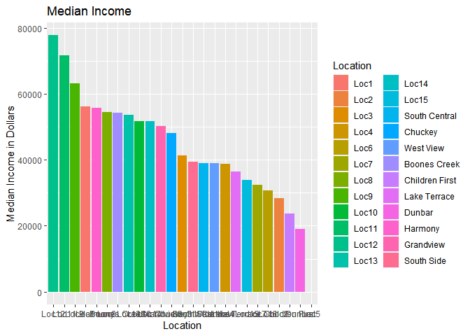

[interactive chart not shown]

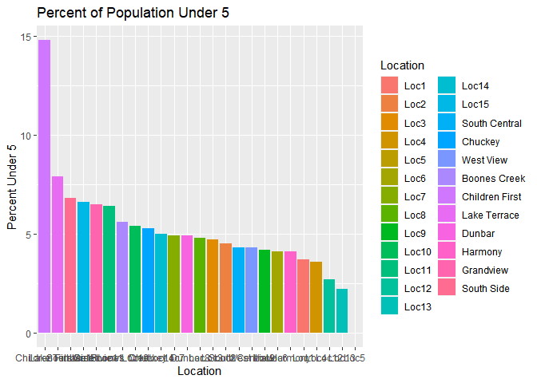

[interactive chart not shown]

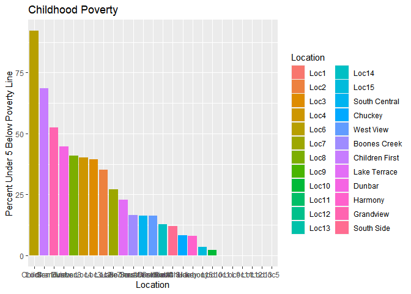

[interactive chart not shown]

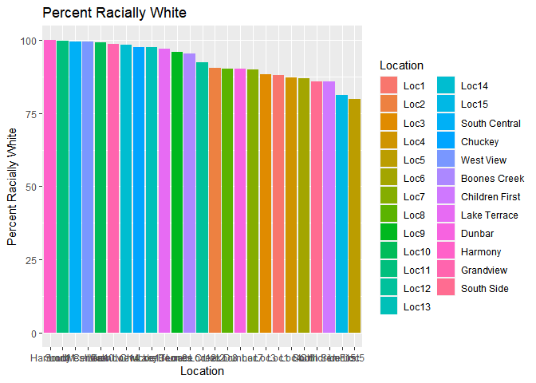

[interactive chart not shown]

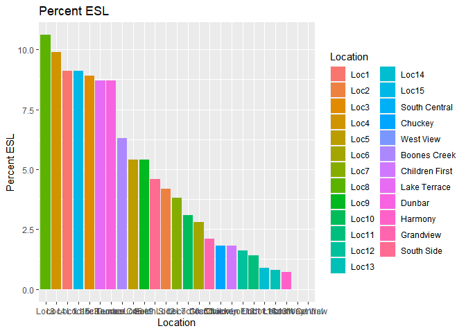

[interactive chart not shown]

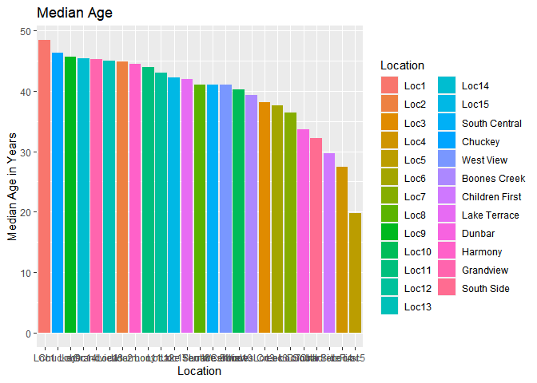

[interactive chart not shown]

# Map of Candidate Tracts

[interactive chart not shown]

# Data Table of Candidate Tracts

|  | Measure | Head Start Location | Census Tract | Count | Margin of Error | Percent | Percent Margin of Error |
| --- | --- | --- | --- | --- | --- | --- | --- |
| 1 | Grandparent living in household and responsible for children under 1 | Loc6 | Census Tract 610, Washington County, Tennessee | 0 | 12 | 0 | 36.4 |
| 2 | Grandparent living in household and responsible for children 1-2 years old | Loc6 | Census Tract 610, Washington County, Tennessee | 0 | 12 | 0 | 36.4 |
| 3 | Grandparent living in household and responsible for children 3-4 years olds | Loc6 | Census Tract 610, Washington County, Tennessee | 17 | 26 | 23.9 | 51.7 |
| 4 | Children enrolled in preschool or nursery school | Loc6 | Census Tract 610, Washington County, Tennessee | 16 | 19 | 3.1 | 3.7 |
| 5 | Citizens with a Disability | Loc6 | Census Tract 610, Washington County, Tennessee | 529 | 155 | 21.2 | 6.2 |
| 6 | Population ESL | Loc6 | Census Tract 610, Washington County, Tennessee | 66 | 69 | 2.8 | 2.8 |
| 7 | Households with a Computer | Loc6 | Census Tract 610, Washington County, Tennessee | 858 | 139 | 82.1 | 8.3 |
| 8 | Households with Broadband internet | Loc6 | Census Tract 610, Washington County, Tennessee | 745 | 142 | 71.3 | 9.2 |
| 9 | Unemployment Rate | Loc6 | Census Tract 610, Washington County, Tennessee |  |  | 7 | 5 |
| 10 | Median Income | Loc6 | Census Tract 610, Washington County, Tennessee | 30637 | 7356 |  |  |

[output cut: 98 more lines]

# Tract 610

Census tract 610 is located along East Unaka and East Watauga Ave in Johnson City. The median income was $30,637 (21 of 25). The poverty rate for children under 5 was 92.1% (25 of 25), and 29.9% of all households are below the poverty line (23 of 25). The 5 year aggregate unemployment rate was 7% (18 of 25). 4.1% of the population was below 5 years of age (20 of 25), and 2.8% of the population are ESL (15 of 25). 30.2% of households receive SNAP benefits (4 of 25). 86.8% of the population is racially white, the 5th lowest in Washington County (5 of 25), and the median age was 37.6 (7 of 25).

When compared with the tract containing Children First, the only statistically significant difference was Children First had 14.6% of its population under the age of 5, while tract 610 had 4.1%. When compared with the tract containing Dunbar, there were two statistically significant differences. Dunbar had a higher ESL population percentage (8.7% vs. 2.8%) and tract 610 had a higher poverty rate for children under 5 (92.1% vs 44.8%). These tests suggest a strong need for a Head Start Location in this area.

|  | Measure | Head Start Location | Census Tract | Count | Margin of Error | Percent | Percent Margin of Error |
| --- | --- | --- | --- | --- | --- | --- | --- |
| 1 | Grandparent living in household and responsible for children under 1 | Loc6 | Census Tract 610, Washington County, Tennessee | 0 | 12 | 0 | 36.4 |
| 2 | Grandparent living in household and responsible for children 1-2 years old | Loc6 | Census Tract 610, Washington County, Tennessee | 0 | 12 | 0 | 36.4 |
| 3 | Grandparent living in household and responsible for children 3-4 years olds | Loc6 | Census Tract 610, Washington County, Tennessee | 17 | 26 | 23.9 | 51.7 |
| 4 | Children enrolled in preschool or nursery school | Loc6 | Census Tract 610, Washington County, Tennessee | 16 | 19 | 3.1 | 3.7 |
| 5 | Citizens with a Disability | Loc6 | Census Tract 610, Washington County, Tennessee | 529 | 155 | 21.2 | 6.2 |
| 6 | Population ESL | Loc6 | Census Tract 610, Washington County, Tennessee | 66 | 69 | 2.8 | 2.8 |
| 7 | Households with a Computer | Loc6 | Census Tract 610, Washington County, Tennessee | 858 | 139 | 82.1 | 8.3 |
| 8 | Households with Broadband internet | Loc6 | Census Tract 610, Washington County, Tennessee | 745 | 142 | 71.3 | 9.2 |
| 9 | Unemployment Rate | Loc6 | Census Tract 610, Washington County, Tennessee |  |  | 7 | 5 |
| 10 | Median Income | Loc6 | Census Tract 610, Washington County, Tennessee | 30637 | 7356 |  |  |

[output cut: 8 more lines]

# Tract 613

Census tract 613 is located in the area along Bristol Highway up to Interstate 26 in Johnson City. The median income was $54,567 (8 of 25) and the poverty rate for children under 5 was 40.9% (21 of 25). 9.3% (11 of 25) of all households were below the poverty line. The 5 year aggregate unemployment rate was 4.9% (14 of 25). 4.8% of the population was below 5 years of age (13 of 25), and 10.6% of the population are ESL (1 of 25), the highest in Washington County. 5.2% of households receive SNAP benefits (24 of 25). 90.3% of the population is racially white (11 of 25), and the median age is 41.1 (11 of 25).

When compared with the tract containing Children First, tract 613 had significantly lower percentage of families receiving SNAP benefits, significantly lower percentage of population under 5, significantly lower percentage of all families below the poverty line, a significantly higher ESL population, and a significantly higher median income. When compared with Dunbar, tract 613 had a significantly lower 5 year aggregate unemployment rate, significantly higher median income, significantly lower percentage of families below the poverty line, and a significantly higher median age.

|  | Measure | Head Start Location | Census Tract | Count | Margin of Error | Percent | Percent Margin of Error |
| --- | --- | --- | --- | --- | --- | --- | --- |
| 1 | Grandparent living in household and responsible for children under 1 | Loc8 | Census Tract 613, Washington County, Tennessee | 0 | 17 | 0 | 45.9 |
| 2 | Grandparent living in household and responsible for children 1-2 years old | Loc8 | Census Tract 613, Washington County, Tennessee | 15 | 24 | 33.3 | 52.2 |
| 3 | Grandparent living in household and responsible for children 3-4 years olds | Loc8 | Census Tract 613, Washington County, Tennessee | 0 | 17 | 0 | 45.9 |
| 4 | Children enrolled in preschool or nursery school | Loc8 | Census Tract 613, Washington County, Tennessee | 163 | 93 | 7.3 | 4.1 |
| 5 | Citizens with a Disability | Loc8 | Census Tract 613, Washington County, Tennessee | 1266 | 353 | 15.3 | 3.9 |
| 6 | Population ESL | Loc8 | Census Tract 613, Washington County, Tennessee | 854 | 315 | 10.6 | 3.9 |
| 7 | Households with a Computer | Loc8 | Census Tract 613, Washington County, Tennessee | 3319 | 222 | 93.6 | 2.7 |
| 8 | Households with Broadband internet | Loc8 | Census Tract 613, Washington County, Tennessee | 3112 | 248 | 87.8 | 4.1 |
| 9 | Unemployment Rate | Loc8 | Census Tract 613, Washington County, Tennessee |  |  | 4.9 | 3.4 |
| 10 | Median Income | Loc8 | Census Tract 613, Washington County, Tennessee | 54567 | 11245 |  |  |

[output cut: 8 more lines]

# Tract 606

Census tract 606 is located south of ETSU and boarders Carter County. The median income was $38,704 (17 of 25). The poverty rate for children under 5 was 40.1% (20 of 25). 18.2% (19 of 25) of all households were below the poverty line. The 5 year aggregate unemployment rate was 8.6% (21 of 25). 3.6% of the population was below 5 years of age (22 of 25), and 9.9% of the population are ESL (2 of 25). 10.4% of the population receive SNAP benefits (16 of 25), 87.1% of the population is racially white (6 of 25), and the median age is 27.4 (2 of 25), the lowest in Washington County outside of the track containing ETSU.

When compared with Children First, census tract 606 had a significantly lower percentage of total households receiving SNAP benefits, percentage of the population below age 5, significantly lower percentage of all families below the poverty line, and significantly higher median income. When compared with Dunbar, census tract 606 had significantly lower percentage of families with SNAP benefits, percentage of families below the poverty line, and a significantly higher median income.

|  | Measure | Head Start Location | Census Tract | Count | Margin of Error | Percent | Percent Margin of Error |
| --- | --- | --- | --- | --- | --- | --- | --- |
| 1 | Grandparent living in household and responsible for children under 1 | Loc4 | Census Tract 606, Washington County, Tennessee | 0 | 17 | 0 | 41.1 |
| 2 | Grandparent living in household and responsible for children 1-2 years old | Loc4 | Census Tract 606, Washington County, Tennessee | 0 | 17 | 0 | 41.1 |
| 3 | Grandparent living in household and responsible for children 3-4 years olds | Loc4 | Census Tract 606, Washington County, Tennessee | 28 | 41 | 50 | 50 |
| 4 | Children enrolled in preschool or nursery school | Loc4 | Census Tract 606, Washington County, Tennessee | 14 | 25 | 0.4 | 0.8 |
| 5 | Citizens with a Disability | Loc4 | Census Tract 606, Washington County, Tennessee | 1179 | 236 | 15.6 | 3.1 |
| 6 | Population ESL | Loc4 | Census Tract 606, Washington County, Tennessee | 718 | 288 | 9.9 | 3.8 |
| 7 | Households with a Computer | Loc4 | Census Tract 606, Washington County, Tennessee | 2813 | 216 | 92.1 | 3.9 |
| 8 | Households with Broadband internet | Loc4 | Census Tract 606, Washington County, Tennessee | 2528 | 191 | 82.8 | 4.2 |
| 9 | Unemployment Rate | Loc4 | Census Tract 606, Washington County, Tennessee |  |  | 8.6 | 4.1 |
| 10 | Median Income | Loc4 | Census Tract 606, Washington County, Tennessee | 38704 | 4963 |  |  |

[output cut: 8 more lines]

# Tract 605.02

When compared with Children First, tract 605.02 had a significantly higher percentage of ESL, a significantly lower 5 year aggregate unemployment rate, significantly lower percentage of families receiving SNAP benefits, significantly lower percentage of families below the poverty line, significantly lower percentage of the population below age 5, and a significantly higher median income. When compared with Dunbar, tract 605.02 had a significantly lower 5 year aggregate unemployment rate, significantly lower percentage of families receiving SNAP benefits, significantly lower percentage of all families below the poverty line, and significantly higher median income.

|  | Measure | Head Start Location | Census Tract | Count | Margin of Error | Percent | Percent Margin of Error |
| --- | --- | --- | --- | --- | --- | --- | --- |
| 1 | Grandparent living in household and responsible for children under 1 | Loc3 | Census Tract 605.02, Washington County, Tennessee | 0 | 17 | 0 | 29 |
| 2 | Grandparent living in household and responsible for children 1-2 years old | Loc3 | Census Tract 605.02, Washington County, Tennessee | 0 | 17 | 0 | 29 |
| 3 | Grandparent living in household and responsible for children 3-4 years olds | Loc3 | Census Tract 605.02, Washington County, Tennessee | 0 | 17 | 0 | 29 |
| 4 | Children enrolled in preschool or nursery school | Loc3 | Census Tract 605.02, Washington County, Tennessee | 59 | 88 | 4.1 | 5.3 |
| 5 | Citizens with a Disability | Loc3 | Census Tract 605.02, Washington County, Tennessee | 1008 | 267 | 17.1 | 4.3 |
| 6 | Population ESL | Loc3 | Census Tract 605.02, Washington County, Tennessee | 498 | 232 | 8.9 | 4.1 |
| 7 | Households with a Computer | Loc3 | Census Tract 605.02, Washington County, Tennessee | 2382 | 199 | 88.4 | 5.3 |
| 8 | Households with Broadband internet | Loc3 | Census Tract 605.02, Washington County, Tennessee | 2143 | 254 | 79.5 | 7.9 |
| 9 | Unemployment Rate | Loc3 | Census Tract 605.02, Washington County, Tennessee |  |  | 3.7 | 3.1 |
| 10 | Median Income | Loc3 | Census Tract 605.02, Washington County, Tennessee | 41413 | 8083 |  |  |

[output cut: 8 more lines]

# Tract 605.01

Census tract 605.01 is located in the West Market Street area on the Western side of State of Franklin Road. The median income was $28,349 (23 of 25), the lowest in Washington County without a Head Start Location. The poverty rate for children under 5 was 35% (18 of 25). 19.8% (20 of 25) of all households were below the poverty line. The 5 year aggregate unemployment rate was 6% (16 of 25). 4.5% of the population was below 5 years of age (15 of 25), and 4.2% of the population are ESL (12 of 25). 23% of the population receive SNAP benefits (5 of 25), 90.5% of the population is racially white (12 of 25), and the median age is 44.9 (19 of 25).

When compared with Children First, tract 605.01 had significantly lower percentage of families receiving SNAP benefits, lower percentage of all families below the poverty line, lower percentage of population under age 5, and significantly higher median age. When compared with Dunbar, tract 605.01 had significantly lower 5-year aggregate unemployment rate, significantly higher median age, and significantly higher median income.

|  | Measure | Head Start Location | Census Tract | Count | Margin of Error | Percent | Percent Margin of Error |
| --- | --- | --- | --- | --- | --- | --- | --- |
| 1 | Grandparent living in household and responsible for children under 1 | Loc2 | Census Tract 605.01, Washington County, Tennessee | 0 | 12 | 0 | 40.1 |
| 2 | Grandparent living in household and responsible for children 1-2 years old | Loc2 | Census Tract 605.01, Washington County, Tennessee | 0 | 12 | 0 | 40.1 |
| 3 | Grandparent living in household and responsible for children 3-4 years olds | Loc2 | Census Tract 605.01, Washington County, Tennessee | 0 | 12 | 0 | 40.1 |
| 4 | Children enrolled in preschool or nursery school | Loc2 | Census Tract 605.01, Washington County, Tennessee | 63 | 56 | 5.2 | 4.9 |
| 5 | Citizens with a Disability | Loc2 | Census Tract 605.01, Washington County, Tennessee | 1291 | 312 | 27.8 | 6 |
| 6 | Population ESL | Loc2 | Census Tract 605.01, Washington County, Tennessee | 190 | 111 | 4.2 | 2.4 |
| 7 | Households with a Computer | Loc2 | Census Tract 605.01, Washington County, Tennessee | 1830 | 209 | 83 | 5.3 |
| 8 | Households with Broadband internet | Loc2 | Census Tract 605.01, Washington County, Tennessee | 1671 | 210 | 75.7 | 6 |
| 9 | Unemployment Rate | Loc2 | Census Tract 605.01, Washington County, Tennessee |  |  | 6 | 4.8 |
| 10 | Median Income | Loc2 | Census Tract 605.01, Washington County, Tennessee | 28349 | 2863 |  |  |

[output cut: 8 more lines]

# Tract 620

Census tract 620 is located near the Clark Manor neighborhood. The median income was $33,947 (20 of 25). The poverty rate for children under 5 was only 3.5% (8 of 25) but not significantly different than the rate for the tract containing the Harmony classroom (8%). 9.4% (12 of 25) of all households were below the poverty line. The 5-year aggregate unemployment rate was 5.7% (15 of 25). 6.6% of the population was below 5 years of age (4 of 25), and 9.1% of the population are ESL (3 of 25). 16.7% of the population receive SNAP benefits (9 of 25), 81.3% of the population is racially white (2 of 25) and the median age is 42.3 (15 of 25).

When compared with Children First, census tract 620 had a significantly higher ESL population, significantly lower percentage of households receiving SNAP benefits, significantly lower percentage of total families below the poverty line, significantly lower total population under age 5, significantly higher median age and median income. When compared with Dunbar, tract 620 had a significantly higher median income, significantly lower unemployment rate, significantly lower total households receiving SNAP benefits, significantly lower poverty rate for children under 5 and all families, and significantly lower population that is racially white.

|  | Measure | Head Start Location | Census Tract | Count | Margin of Error | Percent | Percent Margin of Error |
| --- | --- | --- | --- | --- | --- | --- | --- |
| 1 | Grandparent living in household and responsible for children under 1 | Loc15 | Census Tract 620, Washington County, Tennessee | 11 | 18 | 28.9 | 50.7 |
| 2 | Grandparent living in household and responsible for children 1-2 years old | Loc15 | Census Tract 620, Washington County, Tennessee | 0 | 12 | 0 | 49.9 |
| 3 | Grandparent living in household and responsible for children 3-4 years olds | Loc15 | Census Tract 620, Washington County, Tennessee | 14 | 23 | 36.8 | 44.4 |
| 4 | Children enrolled in preschool or nursery school | Loc15 | Census Tract 620, Washington County, Tennessee | 19 | 20 | 3 | 3.1 |
| 5 | Citizens with a Disability | Loc15 | Census Tract 620, Washington County, Tennessee | 936 | 240 | 27.8 | 7.2 |
| 6 | Population ESL | Loc15 | Census Tract 620, Washington County, Tennessee | 295 | 175 | 9.1 | 5.4 |
| 7 | Households with a Computer | Loc15 | Census Tract 620, Washington County, Tennessee | 1498 | 172 | 82.2 | 7.2 |
| 8 | Households with Broadband internet | Loc15 | Census Tract 620, Washington County, Tennessee | 1280 | 187 | 70.3 | 8.8 |
| 9 | Unemployment Rate | Loc15 | Census Tract 620, Washington County, Tennessee |  |  | 5.7 | 3.9 |
| 10 | Median Income | Loc15 | Census Tract 620, Washington County, Tennessee | 33947 | 5532 |  |  |

[output cut: 8 more lines]

# Conclusion